# Stability concerns in random matrices

Brad Duthie

## The effect of increasing numbers of evolutionary traits on eco-evolutionary stability

Recently, Patel et al. (2018) demonstrated the stability criteria for eco-evolutionary systems. A key result was that an unstable (stable) ecological community could be stabilised (destabilised) by fast eco-evolutionary feedback, assuming the evolutionary system was itself stable. Likewise, Patel et al. (2018) showed that an unstable (stable) evolutionary system could be stabilised (destabilised) by fast ecological feedback, assuming the ecological community was itself stable. **Here I am going to show why the stability criteria for eco-evolutionary systems is such that stable ecological systems are *increasingly* likely to be destablised, and unstable ecological systems are *decreasingly* likely to be stabilised, at higher numbers of species traits**. I will use a random matrix approach similar to that of Allesina and colleagues (Allesina and Levine 2011; Allesina and Tang 2012, 2015). The mathematical concept of what I describe below is not new, and is a similar point to what May (1971) explained nearly half a century ago (that increasing species number decreases stability). Still, this point was not, that I can find, noticed or acknowledged by Patel et al. (2018) when coming up with their stability criteria.

**Hence, the goal here is to demonstrate the inherent destabilising effect of rapid evolution, which can also be interpreted as plasticity (Patel et al. 2018), on ecological communities.**

Assume a community of $n$ species, each with the same evolving trait (e.g., body size). Each species $i$ therefore has its own associated trait $m_{i}$ (originally I was thinking about parental investment – I thought that I had come up with something really interesting, then realised that Parker and Begon (1986) got there first). We can describe the dynamics of a system with two species $i$ and $j$ using the Jacobian matrix $\boldsymbol{J}$ below (Patel et al. 2018),

$$\boldsymbol{J} = \begin{bmatrix}
\boldsymbol{A} & \boldsymbol{B} \\
\boldsymbol{C} & \boldsymbol{D} \\ \end{bmatrix}
= \begin{bmatrix}
\frac{\partial N_{i}W_{i}}{\partial N_{i}} & \frac{\partial N_{i}W_{i}}{\partial N_{j}} & \frac{\partial N_{i}W_{i}}{\partial m_{i}} & \frac{\partial N_{i}W_{i}}{\partial m_{j}} \\
\frac{\partial N_{j}W_{j}}{\partial N_{i}} & \frac{\partial N_{j}W_{j}}{\partial N_{j}} & \frac{\partial N_{j}W_{j}}{\partial m_{i}} & \frac{\partial N_{j}W_{j}}{\partial m_{j}} \\
\varepsilon\frac{\partial m_{i}}{\partial N_{i}} & \varepsilon\frac{\partial m_{i}}{\partial N_{j}} & \varepsilon\frac{\partial m_{i}}{\partial m_{i}} & \varepsilon\frac{\partial m_{i}}{\partial m_{j}} \\
\varepsilon\frac{\partial m_{j}}{\partial N_{i}} & \varepsilon\frac{\partial m_{j}}{\partial N_{j}} & \varepsilon\frac{\partial m_{j}}{\partial m_{i}} & \varepsilon\frac{\partial m_{j}}{\partial m_{j}} \\
\end{bmatrix}.$$

Note that the matrix $\boldsymbol{J}$ can be separated into four separate submatrices. The submatrix $\boldsymbol{A}$ describes the effects that the density of one species has on its own population growth (diagonal) or that of another species (off-diagonal). The submatrix $\boldsymbol{B}$ describes the effect the trait $m$ of each species has on the population growth of itself or another species. The submatrix $\boldsymbol{C}$ describes the effect that the density of a species has on a species’ changing $m$, and $\boldsymbol{D}$ describes the effect that traits have on traits. The value of $\varepsilon$ defines the rate of evolutionary change relative to ecological change; here I will just assume a high value of $\varepsilon$, but the conclusions regarding an increasing number of traits’ effect on a relatively slowly changing ecoogical system will be equally applicable to an incresing number of species in relativley slowly evolving system. I will therefore only assume a high value of $\varepsilon$ for now.

For the whole system (ecology and evolution) to be stable when traits change quickly relative to population densities, evolution by itself $\boldsymbol{D}$ must be stable. This is the case when all of the eigenvalues of $\boldsymbol{D}$ are negative. Additionally, for the system $\boldsymbol{J}$ as a whole to be stable, we need to consider the feedback between ecology and evolution. Patel et al. (2018) showed that the system as a whole is stable when the following is satisfied,

$$s\left(\boldsymbol{A} + \boldsymbol{B}\boldsymbol{D}^{-1}(-\boldsymbol{C})\right) < 0.$$

I am specifically interested in the case in which $\boldsymbol{D}$ is known to be stable. Using random matrices containing element values that are real numbers uniformly distributed between $-4$ and $4$, I will show that rapid evolution is almost never stabilising and almost always destabilising when over six species and their traits $m$ are considered. To do this, I will use the following code, which finds a stable random matrix $\boldsymbol{D}$ and assigns random element values (possibly, but not necessarily stable) to $\boldsymbol{A}$, $\boldsymbol{B}$, and $\boldsymbol{C}$. I will do this for 100000 replicates of species numbers from $n = 2$ to $n = 8$.

```r
random_comm <- function(dm = 2, iter = 10000){
    stabilised_fastevo <- NULL;
    unstabled_fastevo  <- NULL;
    nn           <- dm * dm;
    tot_stabled  <- 0;
    tot_ustabled <- 0;
    tot_eco_stab <- 0;
    stabilised_fastevo <- NULL;
    unstabled_fastevo  <- NULL;
    while(iter > 0){
        stabilised   <- 0;
        unstabilised <- 0;
        Adat <- runif(n = nn, min = -4, max = 4);
        Bdat <- runif(n = nn, min = -4, max = 4);
        Cdat <- runif(n = nn, min = -4, max = 4);
        A    <- matrix(data = Adat, nrow = dm, ncol = dm);
        B    <- matrix(data = Bdat, nrow = dm, ncol = dm);
        C    <- matrix(data = Cdat, nrow = dm, ncol = dm);
        egD  <- 1;
        while(egD >= 0){
             Ddat <- runif(n = nn, min = -4, max = 4);
             D    <- matrix(data = Ddat, nrow = dm, ncol = dm);
             egD  <- max(Re(eigen(D)$values))
        }
        eco_stable       <- max(Re(eigen(A)$values)) < 0;
        slow_evo_maxE    <- max(Re(eigen(A + B %*% solve(D) %*% (-C))$values));
        stable_fast_evo  <- slow_evo_maxE < 0;
        if(eco_stable == FALSE & stable_fast_evo == TRUE){
            list_ele <- length(stabilised_fastevo$A) + 1;
            stabilised_fastevo$A[[list_ele]] <- A;
            stabilised_fastevo$B[[list_ele]] <- B;
            stabilised_fastevo$C[[list_ele]] <- C;
            stabilised_fastevo$D[[list_ele]] <- D;
            stabilised   <- 1;
        }
        if(eco_stable == TRUE & stable_fast_evo == FALSE){
            list_ele <- length(unstabled_fastevo$A) + 1;
            unstabled_fastevo$A[[list_ele]] <- A;
            unstabled_fastevo$B[[list_ele]] <- B;
            unstabled_fastevo$C[[list_ele]] <- C;
            unstabled_fastevo$D[[list_ele]] <- D;
            unstabilised   <- 1;
        }
        if(stabilised == 1){
            tot_stabled <- tot_stabled + 1;
        }
        if(unstabilised == 1){
            tot_ustabled <- tot_ustabled + 1;
        }
        if(eco_stable == TRUE){
            tot_eco_stab <- tot_eco_stab + 1;
        }
        iter <- iter - 1;
    }
    results <- list(ecologically_stable = tot_eco_stab,
                    stabilised = tot_stabled, destabilised = tot_ustabled,
                    stabilised_all   = stabilised_fastevo,
                    destabilised_all = unstabled_fastevo);
    return(results);
}
```

Note that the code above takes a while to run for a large number of species, and this is mostly caused by having to find a random matrix $\boldsymbol{D}$ that is stable. The code first checks whether $\boldsymbol{A}$ is stable, and if it is stable, whether or not eco-evolutionary dynamics destabilise the stable ecological community. If it is not stable, then the code checks whether eco-evolutionary dynamics stabilise the unstable ecological community. As expected (May 1971), ecological stability decreases with an increasing number of species.

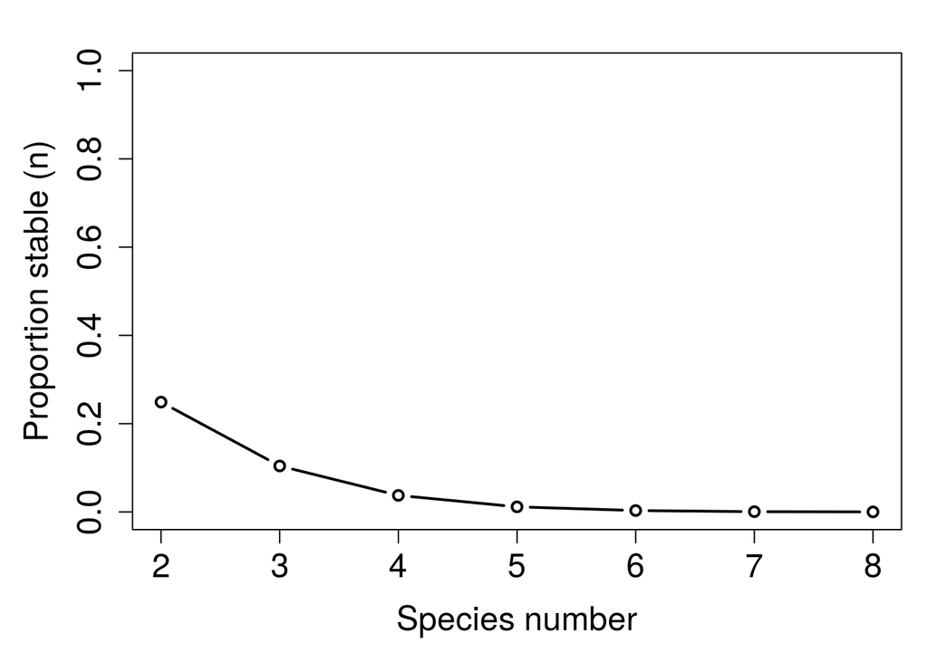

More interesting, the plot below shows eco-evolutionary results for ecological communities that **are** stable. The x-axis shows the number of species in the community (recall that each species has the same evolving trait potentially affecting ecology and evolution), and the y-axis shows the proportion of of these communities that are *destabilised* by eco-evolutionary dynamics.

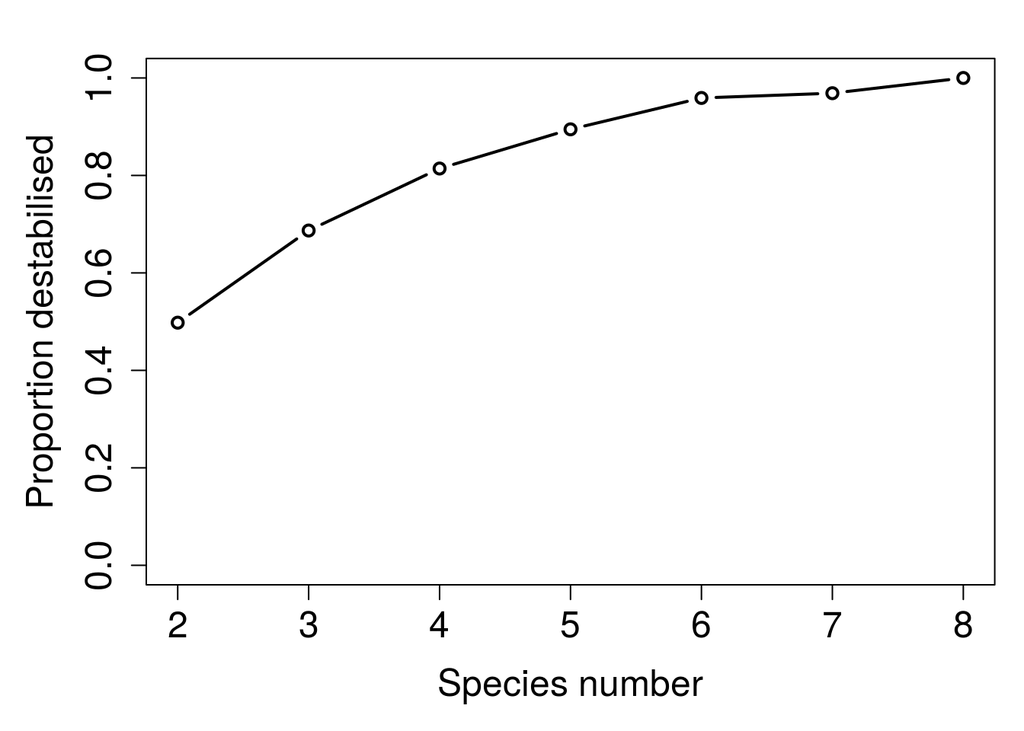

Note that the proportion of communities that are destabilised by eco-evolutionary effects increases with increasing species number. The plot below shows the eco-evolutionary results for ecological communities that are unstable. The y-axis here shows the proportion of communities that are *stabilised* by eco-evolutionary dynamics. This decreases with increasing species number.

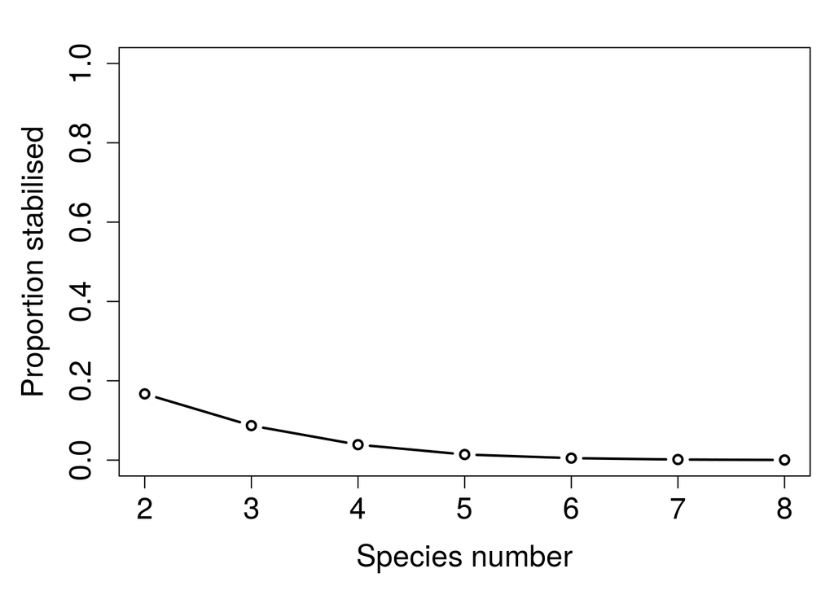

Hence, overall, **as species number and therefore evolving species traits increases, the probability that stable ecological communities become destabilised increases rapidly and the probability that unstable ecological communities are stabilised becomes vanishingly small**. I am not sure if I can prove this mathematically, but I don’t think I need to for the point to be made effectively. What I want to figure out is whether or not this point can or should be published in the peer-reviwed literature – else it’s a blog post.

## References

Allesina, S., and J. M. Levine. 2011. A competitive network theory of species diversity. Proceedings of the National Academy of Sciences of the United States of America 108:5638–5642.

Allesina, S., and S. Tang. 2012. Stability criteria for complex ecosystems. Nature 483:205–208. Nature Publishing Group.

Allesina, S., and S. Tang. 2015. The stability–complexity relationship at age 40: a random matrix perspective. Population Ecology 63–75.

May, R. M. 1971. Stability in multispecies community models. Mathematical Biosciences 12:59–79.

Parker, G. A., and M. Begon. 1986. Optimal egg size and clutch size: effects of environment and maternal phenotype. American Naturalist 128:573–592.

Patel, S., M. H. Cortez, and S. J. Schreiber. 2018. Partitioning the effects of eco-evolutionary feedbacks on community stability. American Naturalist 191:1–29.